# Final Test Performance

- Show All Code
- Hide All Code
- View Source

Bayesian beta-binomial models of the points earned on each question

Author

Jason Geller

Published

October 27, 2026

## What this document does

All participants answered the ten final-test questions (five Polio, five TB). Each answer is scored as the points earned out of the question’s maximum (1–4 points). Because the questions are worth different numbers of points, each question’s score is modelled as points out of its maximum with a **beta-binomial** model: a binomial model for the points earned, with an overdispersion parameter, because a student tends to know all or none of a question’s elements. The estimates are on the probability of earning a point (μ), that is, the expected **proportion of a question’s points**, averaged over the sample.

Two sets of models:

- **Status models (pooled).** Each question is coded by its status for the participant: **Prequestioned** (the topic of the participant’s prequestions), **Non-prequestioned** (the other topic, for participants given prequestions), or **no-prequestion** (participants without prequestions). Prequestioned − no-prequestion is the specific benefit and Non-prequestioned − no-prequestion the general benefit. Status + Topic.
- **Group × Topic models** (preregistered, as are the specific and general benefits): Group (Polio, TB, no-prequestion) × Topic (Polio, TB questions). Reported: the Polio − TB difference within each group (which combines any prequestion effect with differences between the Polio and TB questions) and the interaction contrast, the Polio group’s Polio − TB difference minus the TB group’s (in which the question differences cancel). Their Bayes factors are computed on the response scale (proportion of points), the scale of the estimates.

*Naming:* the paper calls the group without prequestions the **no-prequestion** condition; in the data and code it is labelled `Control`.

Random effects: the maximal structure warranted by the design, by-participant intercepts and Topic slopes and by-question intercepts and Status (or Group) slopes (every question was answered in all three statuses and by all three groups). Status, Group and Topic have equal-prior contrasts (`bayestestR::contr.equalprior_pairs`), so every pairwise difference has the same normal(0, 1.5) prior on the log-odds scale. Bayes factors are Savage–Dickey (`bayestestR::bayesfactor_parameters()`) on the link-scale comparisons from `modelbased`, against draws from the same model sampled from its priors. Shared code is in `R/bayes_helpers.R`; fits are cached in `analysis/brms_cache/`.

## Setup

```r
library(here)
fit_settings <- list(chains = 4, iter = 11000, warmup = 1000, adapt_delta = 0.95, refit = FALSE)
if (exists("params")) {
  fit_settings <- modifyList(fit_settings, params[intersect(names(params), names(fit_settings))])
}
source(here("R", "setup.R"))
source(here("R", "data.R"))
source(here("R", "bayes_helpers.R"))
```

## Data

```r
# One row per participant x question (grade_test.R), analysed participants
test_items <- read_csv(here("data", "derived", "test_scored_items.csv"), show_col_types = FALSE) |>
  filter(et_id %in% levels(dat$participant)) |>
  transmute(participant = factor(et_id),
            condition = factor(recode(et_group, Po = "Polio"), levels = c("Control", "Polio", "TB")),
            topic = factor(topic, levels = c("Polio", "TB")),
            question = factor(questnum), points, max_points) |>
  mutate(status = case_when(condition == "Control" ~ "Control",
                            as.character(topic) == as.character(condition) ~ "Prequestioned",
                            TRUE ~ "Non-prequestioned"),
         status = factor(status, levels = c("Prequestioned", "Non-prequestioned", "Control"))) |>
  equal_prior()
test_items_cond <- cond_coding(test_items)

test_items |>
  group_by(status, topic) |>
  summarise(n = n(), prop_points = sum(points) / sum(max_points), .groups = "drop") |>
  kable(digits = 3, caption = "Observed proportion of points by status and topic")
```

Observed proportion of points by status and topic

| status | topic | n | prop_points |
| --- | --- | --- | --- |
| Prequestioned | Polio | 225 | 0.535 |
| Prequestioned | TB | 230 | 0.543 |
| Non-prequestioned | Polio | 230 | 0.297 |
| Non-prequestioned | TB | 225 | 0.406 |
| Control | Polio | 235 | 0.324 |
| Control | TB | 235 | 0.418 |

## Models

```r
m_test  <- list(final_test = fit_betabin("status + topic", "bayes_status_final_test_bb", test_items))
m_topic <- list(final_test = fit_betabin("condition * topic", "bayes_cond_topic_final_test_bb",
                                         test_items_cond, re = re_test_cond))
```

```r
diag_tab <- bind_rows(diag_model(m_test$final_test, "final_test"),
                      diag_model(m_topic$final_test, "final_test (Group × Topic)"))
diag_tab
```

| model | divergences | max_rhat | min_ess_bulk |
| --- | --- | --- | --- |
| final_test | 0 | 1.000787 | 8606.928 |
| final_test (Group × Topic) | 0 | 1.000939 | 7825.949 |

### Choice of model: posterior predictive checks

Questions are worth 1–4 points, so a score can only take a few values (0, .25, .33, .5, .67, .75, 1). The beta-binomial is compared with a binomial model (no overdispersion), with the same predictors and random effects, by how well each reproduces how often each score occurred.

```r
m_bin <- fit_brm(as.formula(paste("points | trials(max_points) ~ status + topic +", re_test)),
                 test_items, binomial(),
                 c(prior_string(sprintf("normal(0, %s)", s_logit), class = "b"),
                   prior(normal(0, 1.5), class = "Intercept"), prior(student_t(3, 0, 1), class = "sd"),
                   prior(lkj(2), class = "cor")),
                 "bayes_status_final_test_binomial")
```

```r
set.seed(2026)
nd <- 1000
obs_prop <- test_items$points / test_items$max_points
max_mat <- matrix(test_items$max_points, nd, nrow(test_items), byrow = TRUE)
yrep <- list(`Beta-binomial` = posterior_predict(m_test$final_test, ndraws = nd) / max_mat,
             Binomial = posterior_predict(m_bin, ndraws = nd) / max_mat)
score_fit <- imap(yrep, \(y, nm) score_freq(y, obs_prop) |> mutate(model = nm)) |> bind_rows()
score_fit |>
  select(score, observed, model, predicted) |>
  pivot_wider(names_from = model, values_from = predicted) |>
  kable(digits = 3, caption = "Share of responses at each score: observed and predicted (posterior mean)")
```

Share of responses at each score: observed and predicted (posterior mean)

| score | observed | Beta-binomial | Binomial |
| --- | --- | --- | --- |
| 0.00 | 0.338 | 0.337 | 0.315 |
| 0.25 | 0.075 | 0.074 | 0.086 |
| 0.33 | 0.063 | 0.061 | 0.069 |
| 0.50 | 0.081 | 0.092 | 0.103 |
| 0.67 | 0.054 | 0.049 | 0.053 |
| 0.75 | 0.035 | 0.040 | 0.039 |
| 1.00 | 0.354 | 0.348 | 0.335 |

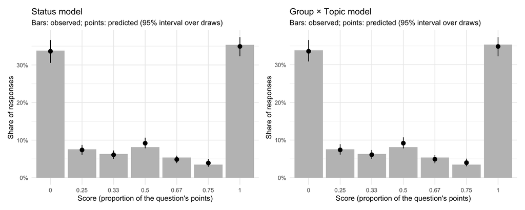

Figure 1

```r
ppc_scores(m_test$final_test, "Status model") + ppc_scores(m_topic$final_test, "Group × Topic model")
```

## Status models: prequestioned and non-prequestioned vs. no-prequestion

```r
bf_tab <- bf_table(m_test)
est_tab <- contrasts_by(m_test)
means_tab <- means_by(m_test, "status")
means_draws <- mean_draws_by(m_test, "status")
bf_tab |> transmute(comparison, BF10, BF01) |> kable(digits = 2)
```

| comparison | BF10 | BF01 |
| --- | --- | --- |
| Prequestioned - Control | 128842342.57 | 0.00 |
| Non-prequestioned - Control | 0.54 | 1.85 |

```r
est_tab
```

| Level1 | Level2 | ROPE_CI | Mean | CI_low | CI_high | pd | ROPE_low | ROPE_high | ROPE_Percentage | model | parameter |
| --- | --- | --- | --- | --- | --- | --- | --- | --- | --- | --- | --- |
| Prequestioned | Control | 0.95 | 0.16667222 | 0.1253902 | 0.207316601 | 1.000000 | -0.1 | 0.1 | 0 | final_test | mu |
| Non-prequestioned | Control | 0.95 | -0.04576569 | -0.0886606 | -0.002820922 | 0.981125 | -0.1 | 0.1 | 1 | final_test | mu |

```r
means_tab
```

| status | ROPE_CI | Mean | CI_low | CI_high | pd | ROPE_low | ROPE_high | ROPE_Percentage | model | parameter |
| --- | --- | --- | --- | --- | --- | --- | --- | --- | --- | --- |
| Prequestioned | 0.95 | 0.6224080 | 0.5931933 | 0.6509184 | 1 | -0.1 | 0.1 | 0 | final_test | mu |
| Non-prequestioned | 0.95 | 0.4099701 | 0.3791263 | 0.4412938 | 1 | -0.1 | 0.1 | 0 | final_test | mu |
| Control | 0.95 | 0.4557357 | 0.4255335 | 0.4856540 | 1 | -0.1 | 0.1 | 0 | final_test | mu |

## Group × Topic

```r
# proportion of points: Bayes factors on the response scale, the scale of the estimates
bf_topic_tab <- bf_table(m_topic, topic_draws, response_scale = "final_test")
est_topic_tab <- topic_estimates(m_topic)
means_topic_tab <- means_by(m_topic, c("condition", "topic")) |> add_status()
means_topic_draws <- mean_draws_by(m_topic, c("condition", "topic")) |> add_status()
bf_topic_tab |> transmute(comparison, BF10, BF01) |> kable(digits = 2)
```

| comparison | BF10 | BF01 |
| --- | --- | --- |
| Polio - TB (Polio group) | 8.617941e+05 | 0.00 |
| Polio - TB (TB group) | 1.561461e+06 | 0.00 |
| Polio - TB (Control group) | 2.800000e-01 | 3.54 |
| Interaction (Polio group - TB group) | 1.496456e+10 | 0.00 |

```r
est_topic_tab
```

| comparison | Mean | CI_low | CI_high | pd | model | parameter |
| --- | --- | --- | --- | --- | --- | --- |
| Polio - TB (Polio group) | 0.19920682 | 0.13801736 | 0.25980535 | 1.000000 | final_test | mu |
| Polio - TB (TB group) | -0.21128237 | -0.27118522 | -0.15072193 | 1.000000 | final_test | mu |
| Polio - TB (Control group) | -0.03594613 | -0.09536416 | 0.02304333 | 0.882925 | final_test | mu |
| Interaction (Polio group - TB group) | 0.41048920 | 0.32438886 | 0.49448423 | 1.000000 | final_test | mu |

```r
means_topic_tab
```

| condition | topic | ROPE_CI | Mean | CI_low | CI_high | pd | ROPE_low | ROPE_high | ROPE_Percentage | model | parameter | status |
| --- | --- | --- | --- | --- | --- | --- | --- | --- | --- | --- | --- | --- |
| Polio | Polio | 0.95 | 0.6443078 | 0.6053303 | 0.6810539 | 1 | -0.1 | 0.1 | 0 | final_test | mu | Prequestioned |
| Polio | TB | 0.95 | 0.4451010 | 0.3977844 | 0.4925177 | 1 | -0.1 | 0.1 | 0 | final_test | mu | Non-prequestioned |
| TB | Polio | 0.95 | 0.3806503 | 0.3394976 | 0.4216979 | 1 | -0.1 | 0.1 | 0 | final_test | mu | Non-prequestioned |
| TB | TB | 0.95 | 0.5919327 | 0.5466943 | 0.6353187 | 1 | -0.1 | 0.1 | 0 | final_test | mu | Prequestioned |
| Control | Polio | 0.95 | 0.4388538 | 0.4005047 | 0.4774850 | 1 | -0.1 | 0.1 | 0 | final_test | mu | Control |
| Control | TB | 0.95 | 0.4748000 | 0.4295509 | 0.5197007 | 1 | -0.1 | 0.1 | 0 | final_test | mu | Control |

## Prior sensitivity

```r
sens_tab <- sens_table(c(m_test, set_names(m_topic, "final_test (Group × Topic)")))
sens_tab
```

| variable | prior | likelihood | diagnosis | model |
| --- | --- | --- | --- | --- |
| b_Intercept | 0.02380132 | 0.02374688 | no issue | final_test |
| b_status1 | 0.01763945 | 0.04340276 | no issue | final_test |
| b_status2 | 0.03099020 | 0.07374410 | no issue | final_test |
| b_topic1 | 0.04373429 | 0.02326144 | no issue | final_test |
| b_Intercept | 0.02764923 | 0.02151867 | no issue | final_test (Group × Topic) |
| b_condition1 | 0.01644969 | 0.03637405 | no issue | final_test (Group × Topic) |
| b_condition2 | 0.02959244 | 0.07044854 | no issue | final_test (Group × Topic) |
| b_topic1 | 0.03502260 | 0.01959176 | no issue | final_test (Group × Topic) |
| b_condition1:topic1 | 0.03179572 | 0.04012898 | no issue | final_test (Group × Topic) |
| b_condition2:topic1 | 0.05371083 | 0.07702565 | potential prior-likelihood conflict | final_test (Group × Topic) |

## Results file

```r
save_results(list(diag = diag_tab, bf = bf_tab, est = est_tab, means = means_tab,
                  means_draws = means_draws, bf_topic = bf_topic_tab, est_topic = est_topic_tab,
                  means_topic = means_topic_tab, means_topic_draws = means_topic_draws,
                  score_fit = score_fit,
                  sens = sens_tab),
             here("analysis", "results_final_test.rds"))
```